# Web Scraping Project on Bike Details

## importing the libraries

```python
import re
import numpy as np
import pandas as pd
import matplotlib.pyplot as plt
import seaborn as sns
from bs4 import BeautifulSoup
import requests
import os
import plotly.express as ex
import warnings
warnings.filterwarnings('ignore')
```

```python
from IPython.core.interactiveshell import InteractiveShell
InteractiveShell.ast_node_interactivity="all"
```

```python
Model_Name = []
Rating = []
No_of_Ratings = []
Details = []
Price =[]
Location = []
for page in range(1,12):
    url = f'https://www.bikewale.com/new-bike-search/best-100cc-bikes/?sortField1=modelPopularity&sortOrder1=desc&displacementRange=1-100%2C100-110%2C110-125%2C125-150%2C150-200%2C200-250%2C250-500%2C500-10000&startType=853%2C854%2C2129&fuelType=806&pageNumber={page}'
    response = requests.get(url)
    soup = BeautifulSoup(response.text)
    for i in soup.find_all('div',attrs={'class':'o-f7 o-o'}):
        mname = i.find('span',attrs={'class':'o-jJ o-j3 o-js o-ez'})
        rat = i.find('p',attrs={'class':'o-j1 o-cx o-jq o-d o-j o-jJ'})
        Nrat = i.find('span',attrs={'class':'o-jL o-f7 o-j0 o-jc o-fE'})
        cc = i.find('div',attrs={'class':'o-o FTJfQA o-iT o-ei'})
        price = i.find('span',attrs={'class':'o-jJ o-jr o-j3 o-kJ'})
        loc = i.find('div',attrs={'class':'o-o FTJfQA o-hj o-iT o-jK o-j1'})

        Model_Name.append(mname.text if mname else np.nan)
        Rating.append(rat.text if rat else np.nan )
        No_of_Ratings.append(Nrat.text if Nrat else np.nan)
        Details.append(cc.text if cc else np.nan)
        Price.append(price.text if price else np.nan)
        Location.append(loc.text if loc else np.nan)
```

## Scraping data from web page

- The web page has 11 pages and each page has around 30 bikes in it.
- Each bike has model name, ratings,cc,mileage,weight,price in it.

```python
df= pd.DataFrame({'Model_Name':Model_Name,
                    'Rating' :Rating,
                    'No_of_Ratings' :No_of_Ratings,
                    'Details':Details,
                    'Price' :Price,
                    'Location' : Location})
```

- Converting the data into Dataframe.

```python
df
```

[output not shown]

329 rows × 6 columns

- Saving it into a csv file

```python
df.to_csv('bike.csv',index=False)
```

```python
bike_df = pd.read_csv('bike.csv')
```

- Reading the csv file into bike_df.

```python
bike_df
```

|  | Model_Name | Rating | No_of_Ratings | Details | Price | Location |
| --- | --- | --- | --- | --- | --- | --- |
| 0 | Royal Enfield Bullet 350 | 4.7/5 | 237 Ratings | 349 cc\|35 kmpl\|20.2 bhp\|195 kg | ₹ 1,62,170 | Avg. Ex-Showroom price |
| 1 | Royal Enfield Hunter 350 | 4.7/5 | 193 Ratings | 349.34 cc\|36.2 kmpl\|20.2 bhp\|181 kg | ₹ 1,37,648 | Avg. Ex-Showroom price |
| 2 | Royal Enfield Classic 350 | 4.7/5 | 195 Ratings | 349 cc\|35 kmpl\|20.2 bhp\|195 kg | ₹ 1,81,129 | Avg. Ex-Showroom price |
| 3 | Honda SP 125 | 4.6/5 | 879 Ratings | 123.94 cc\|63 kmpl\|10.72 bhp\|117 kg | ₹ 86,446 | Avg. Ex-Showroom price |
| 4 | Royal Enfield Continental GT 650 | 4.8/5 | 286 Ratings | 648 cc\|25 kmpl\|47 bhp\|211 kg | ₹ 3,49,212 | Avg. Ex-Showroom price |
| ... | ... | ... | ... | ... | ... | ... |
| 324 | KTM 65 SX | NaN | NaN | 64.9 cc\|11.2 bhp\|62 kg | ₹ 5,46,500 | Avg. Ex-Showroom price |
| 325 | Ducati Scrambler Icon | NaN | NaN | 803 cc\|19 kmpl\|71.87 bhp\|185 kg | ₹ 10,65,200 | Avg. Ex-Showroom price |
| 326 | Indian Sport Scout Sixty | NaN | NaN | 999 cc\|86.18 bhp\|241 kg | ₹ 14,19,237 | Avg. Ex-Showroom price |
| 327 | Indian Sport Scout | NaN | NaN | 1250 cc\|106.46 bhp\|248 kg | ₹ 15,05,802 | Avg. Ex-Showroom price |
| 328 | Indian 101 Scout | NaN | NaN | 1250 cc\|112.54 bhp\|249 kg | ₹ 17,08,855 | Avg. Ex-Showroom price |

329 rows × 6 columns

## Replacing the values:

- The data has some unwanted text init.
- So by using the .replace we are replacing the unwanted text with "".

```python
bike_df['Rating'] = bike_df['Rating'].str.replace("/5","")
bike_df['No_of_Ratings'] = bike_df['No_of_Ratings'].str.replace(" Ratings","")
bike_df['Price'] = bike_df['Price'].str.replace("₹ ","")
bike_df['Price'] = bike_df['Price'].str.replace(",","")
```

```python
bike_df
```

|  | Model_Name | Rating | No_of_Ratings | Details | Price | Location |
| --- | --- | --- | --- | --- | --- | --- |
| 0 | Royal Enfield Bullet 350 | 4.7 | 237 | 349 cc\|35 kmpl\|20.2 bhp\|195 kg | 162170 | Avg. Ex-Showroom price |
| 1 | Royal Enfield Hunter 350 | 4.7 | 193 | 349.34 cc\|36.2 kmpl\|20.2 bhp\|181 kg | 137648 | Avg. Ex-Showroom price |
| 2 | Royal Enfield Classic 350 | 4.7 | 195 | 349 cc\|35 kmpl\|20.2 bhp\|195 kg | 181129 | Avg. Ex-Showroom price |
| 3 | Honda SP 125 | 4.6 | 879 | 123.94 cc\|63 kmpl\|10.72 bhp\|117 kg | 86446 | Avg. Ex-Showroom price |
| 4 | Royal Enfield Continental GT 650 | 4.8 | 286 | 648 cc\|25 kmpl\|47 bhp\|211 kg | 349212 | Avg. Ex-Showroom price |
| ... | ... | ... | ... | ... | ... | ... |
| 324 | KTM 65 SX | NaN | NaN | 64.9 cc\|11.2 bhp\|62 kg | 546500 | Avg. Ex-Showroom price |
| 325 | Ducati Scrambler Icon | NaN | NaN | 803 cc\|19 kmpl\|71.87 bhp\|185 kg | 1065200 | Avg. Ex-Showroom price |
| 326 | Indian Sport Scout Sixty | NaN | NaN | 999 cc\|86.18 bhp\|241 kg | 1419237 | Avg. Ex-Showroom price |
| 327 | Indian Sport Scout | NaN | NaN | 1250 cc\|106.46 bhp\|248 kg | 1505802 | Avg. Ex-Showroom price |
| 328 | Indian 101 Scout | NaN | NaN | 1250 cc\|112.54 bhp\|249 kg | 1708855 | Avg. Ex-Showroom price |

329 rows × 6 columns

## Extracting the data:

- The raw data has cc,power,weight,mileage in a single column to extract that we use regular expressions.
- By using this we can have indiviual columns for each detail.

```python
bike_df['Engine_CC'] = bike_df['Details'].apply(lambda x: re.findall('([0-9]+.?[0-9]+) cc',x)[0])
bike_df['Mileage'] = bike_df['Details'].astype(str).apply(
    lambda x: re.findall(r'([0-9]+\.?[0-9]*) kmpl', x)[0] if re.findall(r'([0-9]+\.?[0-9]*) kmpl', x) else np.nan)

bike_df['Power'] = bike_df['Details'].astype(str).apply(
    lambda x: re.findall(r'([0-9]+\.?[0-9]*) bhp', x)[0] if re.findall(r'([0-9]+\.?[0-9]*) bhp', x) else np.nan)

bike_df['Weight'] = bike_df['Details'].astype(str).apply(
    lambda x: re.findall(r'([0-9]+\.?[0-9]*) kg', x)[0] if re.findall(r'([0-9]+\.?[0-9]*) kg', x) else np.nan)
```

## Droping:

- Droping the unwanted columns.

```python
bike_df.drop('Details',axis=1,inplace=True)
bike_df.drop('Location',axis=1,inplace=True)
```

```python
bike_df.head()
```

|  | Model_Name | Rating | No_of_Ratings | Price | Engine_CC | Mileage | Power | Weight |
| --- | --- | --- | --- | --- | --- | --- | --- | --- |
| 0 | Royal Enfield Bullet 350 | 4.7 | 237 | 162170 | 349 | 35 | 20.2 | 195 |
| 1 | Royal Enfield Hunter 350 | 4.7 | 193 | 137648 | 349.34 | 36.2 | 20.2 | 181 |
| 2 | Royal Enfield Classic 350 | 4.7 | 195 | 181129 | 349 | 35 | 20.2 | 195 |
| 3 | Honda SP 125 | 4.6 | 879 | 86446 | 123.94 | 63 | 10.72 | 117 |
| 4 | Royal Enfield Continental GT 650 | 4.8 | 286 | 349212 | 648 | 25 | 47 | 211 |

## Changing the Data types:

- The columns doesn`t have related data type so we use astype to change the it to relate data type.
- I changed most of the columns into float which has float values.

```python
bike_df['Rating'] = bike_df['Rating'].astype(float)
bike_df['No_of_Ratings'] = bike_df['No_of_Ratings'].astype(float)
bike_df['Price'] = bike_df['Price'].astype(int)
bike_df['Mileage'] = bike_df['Mileage'].astype(float)
bike_df['Engine_CC'] = bike_df['Engine_CC'].astype(float)
bike_df['Power'] = bike_df['Power'].astype(float)
bike_df['Weight'] = bike_df['Weight'].astype(float)
```

```python
bike_df.info()
```

```
<class 'pandas.core.frame.DataFrame'>
RangeIndex: 329 entries, 0 to 328
Data columns (total 8 columns):
 #   Column         Non-Null Count  Dtype
---  ------         --------------  -----
 0   Model_Name     329 non-null    object
 1   Rating         274 non-null    float64
 2   No_of_Ratings  274 non-null    float64
 3   Price          329 non-null    int32
 4   Engine_CC      329 non-null    float64
 5   Mileage        261 non-null    float64
 6   Power          319 non-null    float64
 7   Weight         328 non-null    float64
dtypes: float64(6), int32(1), object(1)
memory usage: 19.4+ KB
```

## Missing values:

- Filling the missing values with suitable values like mode, mean of the whole column.

```python
bike_df.isnull().sum()
```

```
Model_Name        0
Rating           55
No_of_Ratings    55
Price             0
Engine_CC         0
Mileage          68
Power            10
Weight            1
dtype: int64
```

```python
bike_df['Rating'].fillna(bike_df['Rating'].mean(),inplace=True)
bike_df['No_of_Ratings'].fillna(bike_df['No_of_Ratings'].mode()[0],inplace=True)
bike_df['Mileage'].fillna(bike_df['Mileage'].mode()[0],inplace=True)
bike_df['Power'].fillna(bike_df['Power'].mode()[0],inplace=True)
bike_df['Weight'].fillna(bike_df['Weight'].mode()[0],inplace=True)
```

```python
bike_df.isna().sum()
```

```
Model_Name       0
Rating           0
No_of_Ratings    0
Price            0
Engine_CC        0
Mileage          0
Power            0
Weight           0
dtype: int64
```

## Duplicates:

- The data does not have any duplicates init.

```python
bike_df.duplicated().sum()
```

```
0
```

## Extracting New Columns:

- created some functions to extract new columns from the available data.
- The function are applied on the dataframe using the .apply() function.

```python
def Price_Category(x):
    if x>600000:
        return "Luxury"
    elif x>350000:
        return "High end"
    elif x>160000:
        return "Mid Range"
    else:
        return "Budget"
```

```python
bike_df['Price_Category']=bike_df['Price'].apply(Price_Category)
```

```python
def Mileage_Category(x):
    if 0<=x<=30:
        return "Low"
    elif 31<=x<=50:
        return "Medium"
    elif 51<=x<=65:
        return "Good"
    else:
        return "Excellent"
```

```python
def Rating_Category(x):
    if 0<=x<=2.5:
        return "Poor"
    elif 2.6<=x<=3.5:
        return "Average"
    elif 3.6<=x<=4.2:
        return "Good"
    else:
        return "Excellent"
```

```python
bike_df['Mileage_Category']=bike_df['Mileage'].apply(Mileage_Category)
bike_df['Rating_Category']=bike_df['Rating'].apply(Rating_Category)
```

```python
bike_df['Brand'] = bike_df['Model_Name'].apply(lambda x:re.findall('[A-z]+',x)[0])
```

```python
bike_df['Brand']=bike_df['Brand'].replace("Royal","Royal Enfield")
```

```python
bike_df
```

|  | Model_Name | Rating | No_of_Ratings | Price | Engine_CC | Mileage | Power | Weight | Price_Category | Mileage_Category | Rating_Category | Brand |
| --- | --- | --- | --- | --- | --- | --- | --- | --- | --- | --- | --- | --- |
| 0 | Royal Enfield Bullet 350 | 4.700000 | 237.0 | 162170 | 349.00 | 35.0 | 20.20 | 195.0 | Mid Range | Medium | Excellent | Royal Enfield |
| 1 | Royal Enfield Hunter 350 | 4.700000 | 193.0 | 137648 | 349.34 | 36.2 | 20.20 | 181.0 | Budget | Medium | Excellent | Royal Enfield |
| 2 | Royal Enfield Classic 350 | 4.700000 | 195.0 | 181129 | 349.00 | 35.0 | 20.20 | 195.0 | Mid Range | Medium | Excellent | Royal Enfield |
| 3 | Honda SP 125 | 4.600000 | 879.0 | 86446 | 123.94 | 63.0 | 10.72 | 117.0 | Budget | Good | Excellent | Honda |
| 4 | Royal Enfield Continental GT 650 | 4.800000 | 286.0 | 349212 | 648.00 | 25.0 | 47.00 | 211.0 | Mid Range | Low | Excellent | Royal Enfield |
| ... | ... | ... | ... | ... | ... | ... | ... | ... | ... | ... | ... | ... |
| 324 | KTM 65 SX | 4.539781 | 2.0 | 546500 | 64.90 | 35.0 | 11.20 | 62.0 | High end | Medium | Excellent | KTM |
| 325 | Ducati Scrambler Icon | 4.539781 | 2.0 | 1065200 | 803.00 | 19.0 | 71.87 | 185.0 | Luxury | Low | Excellent | Ducati |
| 326 | Indian Sport Scout Sixty | 4.539781 | 2.0 | 1419237 | 999.00 | 35.0 | 86.18 | 241.0 | Luxury | Medium | Excellent | Indian |
| 327 | Indian Sport Scout | 4.539781 | 2.0 | 1505802 | 1250.00 | 35.0 | 106.46 | 248.0 | Luxury | Medium | Excellent | Indian |
| 328 | Indian 101 Scout | 4.539781 | 2.0 | 1708855 | 1250.00 | 35.0 | 112.54 | 249.0 | Luxury | Medium | Excellent | Indian |

329 rows × 12 columns

- Saving the cleaned dataframe into another csv file to keep it safe.

```python
bike_df.to_csv("Cleaned_bike.csv",index=False)
```

## Reading the csv file:

```python
bike_df = pd.read_csv('Cleaned_bike.csv')
```

## Information about the dataset:

```python
bike_df.info()
```

```
<class 'pandas.core.frame.DataFrame'>
RangeIndex: 329 entries, 0 to 328
Data columns (total 12 columns):
 #   Column            Non-Null Count  Dtype
---  ------            --------------  -----
 0   Model_Name        329 non-null    object
 1   Rating            329 non-null    float64
 2   No_of_Ratings     329 non-null    float64
 3   Price             329 non-null    int64
 4   Engine_CC         329 non-null    float64
 5   Mileage           329 non-null    float64
 6   Power             329 non-null    float64
 7   Weight            329 non-null    float64
 8   Price_Category    329 non-null    object
 9   Mileage_Category  329 non-null    object
 10  Rating_Category   329 non-null    object
 11  Brand             329 non-null    object
dtypes: float64(6), int64(1), object(5)
memory usage: 31.0+ KB
```

## Describing the data:

- Describe() is used to get the basic statistics about the numerical columns present in the data frame.

```python
bike_df.describe()
```

|  | Rating | No_of_Ratings | Price | Engine_CC | Mileage | Power | Weight |
| --- | --- | --- | --- | --- | --- | --- | --- |
| count | 329.000000 | 329.000000 | 3.290000e+02 | 329.000000 | 329.000000 | 329.000000 | 329.000000 |
| mean | 4.539781 | 82.553191 | 7.994865e+05 | 531.080851 | 34.315623 | 53.566900 | 178.079635 |
| std | 0.403477 | 188.919628 | 1.019398e+06 | 464.637872 | 13.075808 | 52.320511 | 57.658851 |
| min | 1.000000 | 1.000000 | 4.280300e+04 | 49.900000 | 12.000000 | 4.290000 | 45.000000 |
| 25% | 4.500000 | 2.000000 | 1.339680e+05 | 156.000000 | 24.000000 | 13.000000 | 135.000000 |
| 50% | 4.600000 | 9.000000 | 2.970140e+05 | 348.360000 | 35.000000 | 30.570000 | 179.000000 |
| 75% | 4.700000 | 60.000000 | 1.248948e+06 | 853.000000 | 40.000000 | 81.800000 | 209.000000 |
| max | 5.000000 | 1413.000000 | 7.479847e+06 | 2458.000000 | 80.000000 | 215.000000 | 427.000000 |

```python
bike_df.head()
```

|  | Model_Name | Rating | No_of_Ratings | Price | Engine_CC | Mileage | Power | Weight | Price_Category | Mileage_Category | Rating_Category | Brand |
| --- | --- | --- | --- | --- | --- | --- | --- | --- | --- | --- | --- | --- |
| 0 | Royal Enfield Bullet 350 | 4.7 | 237.0 | 162170 | 349.00 | 35.0 | 20.20 | 195.0 | Mid Range | Medium | Excellent | Royal Enfield |
| 1 | Royal Enfield Hunter 350 | 4.7 | 193.0 | 137648 | 349.34 | 36.2 | 20.20 | 181.0 | Budget | Medium | Excellent | Royal Enfield |
| 2 | Royal Enfield Classic 350 | 4.7 | 195.0 | 181129 | 349.00 | 35.0 | 20.20 | 195.0 | Mid Range | Medium | Excellent | Royal Enfield |
| 3 | Honda SP 125 | 4.6 | 879.0 | 86446 | 123.94 | 63.0 | 10.72 | 117.0 | Budget | Good | Excellent | Honda |
| 4 | Royal Enfield Continental GT 650 | 4.8 | 286.0 | 349212 | 648.00 | 25.0 | 47.00 | 211.0 | Mid Range | Low | Excellent | Royal Enfield |

## Getting Insights:

```python
bike_df.sort_values(by='Price',ascending=False).head(1)
bike_df.sort_values(by='Price',ascending=True).head(1)
```

|  | Model_Name | Rating | No_of_Ratings | Price | Engine_CC | Mileage | Power | Weight | Price_Category | Mileage_Category | Rating_Category | Brand |
| --- | --- | --- | --- | --- | --- | --- | --- | --- | --- | --- | --- | --- |
| 164 | Ducati Panigale V4 R | 4.9 | 2.0 | 7479847 | 998.0 | 12.5 | 215.0 | 193.5 | Luxury | Low | Excellent | Ducati |

|  | Model_Name | Rating | No_of_Ratings | Price | Engine_CC | Mileage | Power | Weight | Price_Category | Mileage_Category | Rating_Category | Brand |
| --- | --- | --- | --- | --- | --- | --- | --- | --- | --- | --- | --- | --- |
| 87 | TVS XL 100 Heavy Duty | 4.4 | 71.0 | 42803 | 99.7 | 55.0 | 4.3 | 89.0 | Budget | Good | Excellent | TVS |

```python
bike_df.sort_values(by='Mileage',ascending=True).head(1)
bike_df.sort_values(by='Mileage',ascending=False).head(1)
```

|  | Model_Name | Rating | No_of_Ratings | Price | Engine_CC | Mileage | Power | Weight | Price_Category | Mileage_Category | Rating_Category | Brand |
| --- | --- | --- | --- | --- | --- | --- | --- | --- | --- | --- | --- | --- |
| 171 | Ducati Panigale V4 | 4.8 | 2.0 | 3205100 | 1103.0 | 12.0 | 213.0 | 191.0 | Luxury | Low | Excellent | Ducati |

|  | Model_Name | Rating | No_of_Ratings | Price | Engine_CC | Mileage | Power | Weight | Price_Category | Mileage_Category | Rating_Category | Brand |
| --- | --- | --- | --- | --- | --- | --- | --- | --- | --- | --- | --- | --- |
| 71 | TVS Sport | 4.4 | 401.0 | 61294 | 109.7 | 80.0 | 8.08 | 112.0 | Budget | Excellent | Excellent | TVS |

```python
bike_df.sort_values(by='No_of_Ratings',ascending=False).head(1)
bike_df.sort_values(by='No_of_Ratings',ascending=True).head(1)
```

|  | Model_Name | Rating | No_of_Ratings | Price | Engine_CC | Mileage | Power | Weight | Price_Category | Mileage_Category | Rating_Category | Brand |
| --- | --- | --- | --- | --- | --- | --- | --- | --- | --- | --- | --- | --- |
| 30 | Bajaj Pulsar 150 | 4.5 | 1413.0 | 105361 | 149.5 | 49.0 | 13.8 | 148.0 | Budget | Medium | Excellent | Bajaj |

|  | Model_Name | Rating | No_of_Ratings | Price | Engine_CC | Mileage | Power | Weight | Price_Category | Mileage_Category | Rating_Category | Brand |
| --- | --- | --- | --- | --- | --- | --- | --- | --- | --- | --- | --- | --- |
| 290 | Vespa 150 | 1.0 | 1.0 | 140431 | 149.5 | 35.0 | 11.2 | 115.0 | Budget | Medium | Poor | Vespa |

```python
bike_df.sort_values(by='Power',ascending=False).head(1)
bike_df.sort_values(by='Power',ascending=True).head(1)
```

|  | Model_Name | Rating | No_of_Ratings | Price | Engine_CC | Mileage | Power | Weight | Price_Category | Mileage_Category | Rating_Category | Brand |
| --- | --- | --- | --- | --- | --- | --- | --- | --- | --- | --- | --- | --- |
| 164 | Ducati Panigale V4 R | 4.9 | 2.0 | 7479847 | 998.0 | 12.5 | 215.0 | 193.5 | Luxury | Low | Excellent | Ducati |

|  | Model_Name | Rating | No_of_Ratings | Price | Engine_CC | Mileage | Power | Weight | Price_Category | Mileage_Category | Rating_Category | Brand |
| --- | --- | --- | --- | --- | --- | --- | --- | --- | --- | --- | --- | --- |
| 126 | TVS XL 100 Comfort | 4.2 | 61.0 | 58440 | 99.7 | 55.0 | 4.29 | 89.0 | Budget | Good | Good | TVS |

```python
bike_df.sort_values(by='Weight',ascending=False).head(1)
bike_df.sort_values(by='Weight',ascending=True).head(1)
```

|  | Model_Name | Rating | No_of_Ratings | Price | Engine_CC | Mileage | Power | Weight | Price_Category | Mileage_Category | Rating_Category | Brand |
| --- | --- | --- | --- | --- | --- | --- | --- | --- | --- | --- | --- | --- |
| 267 | BMW R18 | 4.6 | 15.0 | 3472855 | 1802.0 | 17.0 | 89.84 | 427.0 | Luxury | Low | Excellent | BMW |

|  | Model_Name | Rating | No_of_Ratings | Price | Engine_CC | Mileage | Power | Weight | Price_Category | Mileage_Category | Rating_Category | Brand |
| --- | --- | --- | --- | --- | --- | --- | --- | --- | --- | --- | --- | --- |
| 310 | KTM 50 SX | 3.7 | 3.0 | 475000 | 49.9 | 35.0 | 5.3 | 45.0 | High end | Medium | Good | KTM |

```python
bike_df.sort_values(by='Engine_CC',ascending=False).head(1)
bike_df.sort_values(by='Engine_CC',ascending=True).head(1)
```

|  | Model_Name | Rating | No_of_Ratings | Price | Engine_CC | Mileage | Power | Weight | Price_Category | Mileage_Category | Rating_Category | Brand |
| --- | --- | --- | --- | --- | --- | --- | --- | --- | --- | --- | --- | --- |
| 166 | Triumph Rocket 3 | 4.7 | 10.0 | 2248156 | 2458.0 | 14.6 | 165.0 | 304.0 | Luxury | Low | Excellent | Triumph |

|  | Model_Name | Rating | No_of_Ratings | Price | Engine_CC | Mileage | Power | Weight | Price_Category | Mileage_Category | Rating_Category | Brand |
| --- | --- | --- | --- | --- | --- | --- | --- | --- | --- | --- | --- | --- |
| 310 | KTM 50 SX | 3.7 | 3.0 | 475000 | 49.9 | 35.0 | 5.3 | 45.0 | High end | Medium | Good | KTM |

```python
bike_df['Price_Category'].value_counts()
```

```
Price_Category
Luxury       121
Budget       102
Mid Range     81
High end      25
Name: count, dtype: int64
```

```python
bike_df['Mileage_Category'].value_counts()
```

```
Mileage_Category
Medium       166
Low          127
Good          27
Excellent      9
Name: count, dtype: int64
```

```python
bike_df['Rating_Category'].value_counts()
```

```
Rating_Category
Excellent    290
Good          36
Poor           2
Average        1
Name: count, dtype: int64
```

```python
bike_df['Brand'].value_counts()
```

```
Brand
Kawasaki         36
Honda            29
Hero             24
KTM              23
Triumph          22
TVS              19
Ducati           18
Bajaj            18
BMW              15
Royal Enfield    14
Yamaha           14
Harley           12
Aprilia          12
Suzuki           12
Indian           11
Vespa             9
Keeway            8
Yezdi             5
Jawa              5
Zontes            4
Benelli           4
QJ                4
Brixton           4
Moto              3
Husqvarna         2
VLF               1
BSA               1
Name: count, dtype: int64
```

# Visualizations:

## Univariate Analysis

### Numerical Univariate Analysis

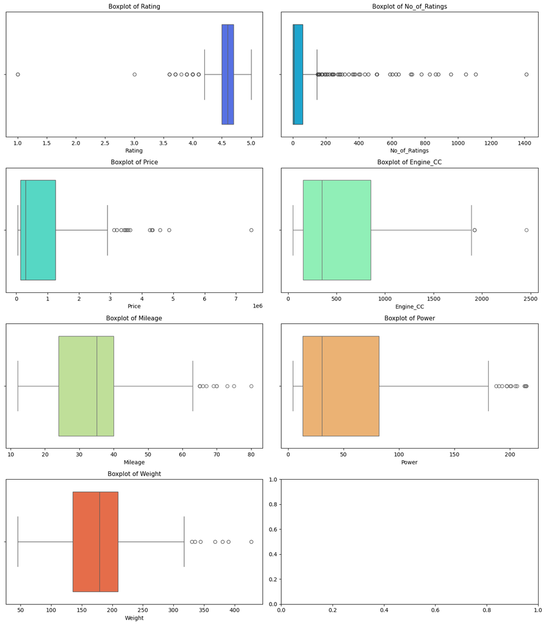

```python
fig, axes = plt.subplots(4, 2, figsize=(14, 16))
axes = axes.flatten()
num_cols = bike_df.select_dtypes('number').columns
colors=sns.color_palette("rainbow",n_colors=len(num_cols))

for i, col in enumerate(num_cols):
    sns.boxplot(data=bike_df, x=col, ax=axes[i],color=colors[i] )
    axes[i].set_title(f'Boxplot of {col}', fontsize=11)
    axes[i].set_xlabel(col)

plt.tight_layout()
plt.show();
```

### Ctegorical Univariate Analysis:

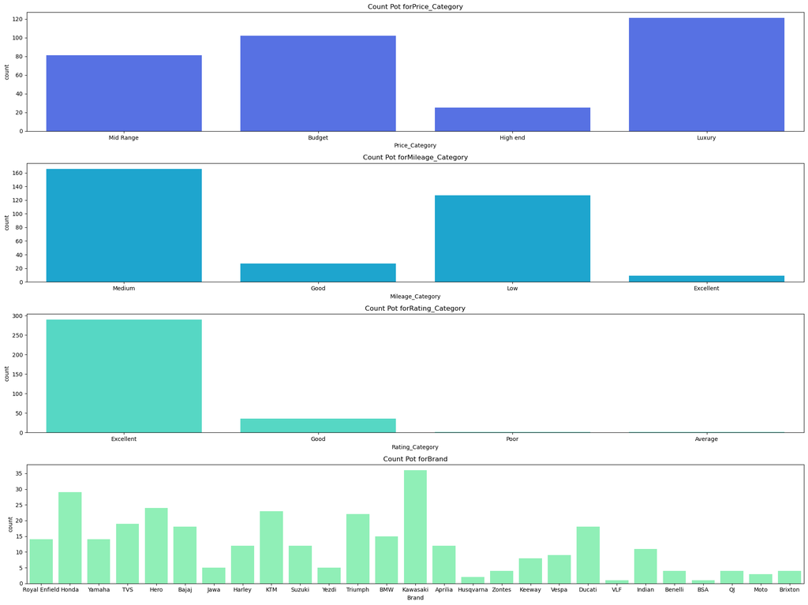

```python
fig,axes = plt.subplots(4,1,figsize=(20,15))
axes=axes.flatten()
cat_col =bike_df.select_dtypes('object').columns[1:]
for i , col in enumerate(cat_col):
    sns.countplot(data=bike_df,x=col,ax=axes[i],color=colors[i])
    axes[i].set_title(f"Count Pot for{col}")
    axes[i].set_xlabel(col)
plt.tight_layout()
plt.show();
```

# Bivariate Analaysis:

## Numerical VS Numerical:

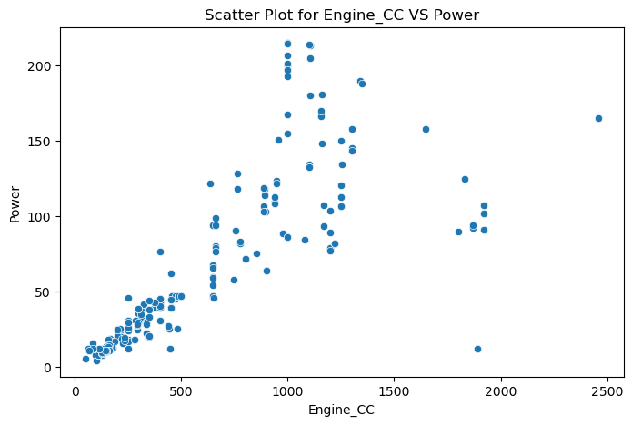

```python
plt.figure(figsize=(8,5))
sns.scatterplot(data=bike_df,x='Engine_CC',y='Power')
plt.title("Scatter Plot for Engine_CC VS Power")
plt.show();
```

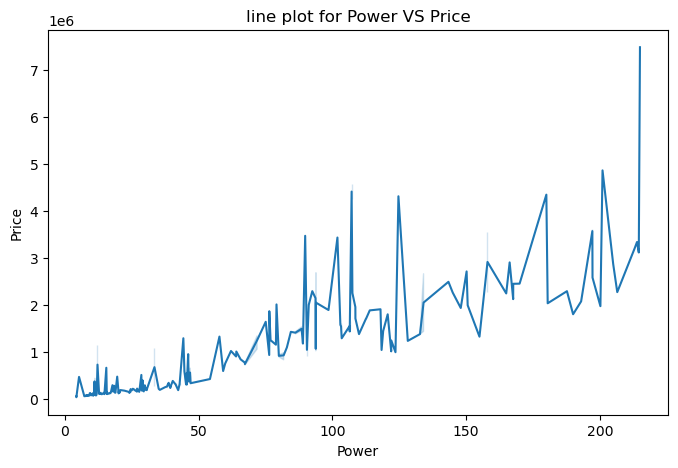

```python
plt.figure(figsize=(8,5))
sns.lineplot(data=bike_df,x='Power',y='Price')
plt.title("line plot for Power VS Price")
plt.show();
```

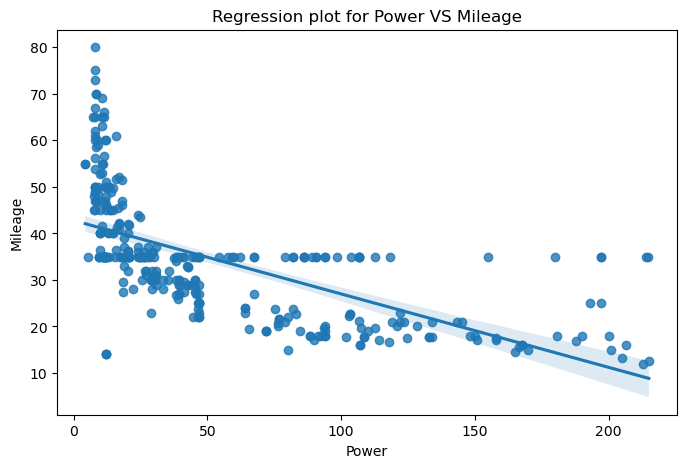

```python
plt.figure(figsize=(8,5))
sns.regplot(data=bike_df,x='Power',y='Mileage')
plt.title("Regression plot for Power VS Mileage")
plt.show();
```

## Numerical VS Categorical

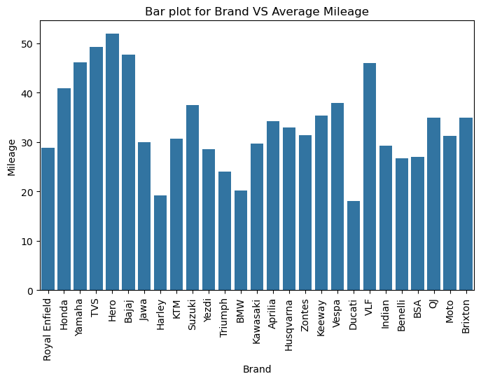

```python
plt.figure(figsize=(8,5))
sns.barplot(data=bike_df,x='Brand',y='Mileage',estimator='mean',ci=False)
plt.title("Bar plot for Brand VS Average Mileage")
plt.xticks(rotation=90)
plt.show();
```

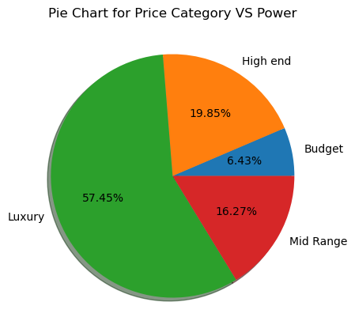

```python
p=bike_df.groupby("Price_Category")['Power'].mean()
plt.figure(figsize=(8,5))
plt.pie(x=p,autopct='%.2f%%',labels=p.index,shadow=True)
plt.title("Pie Chart for Price Category VS Power")
plt.show();
```

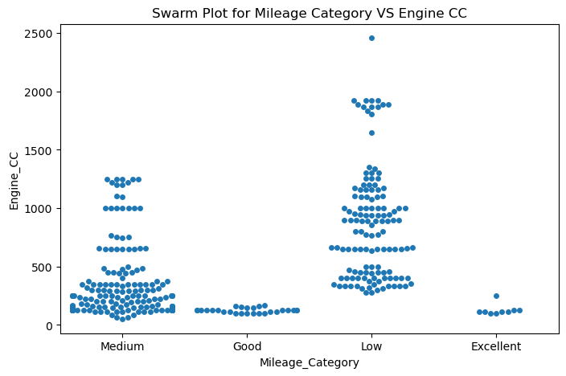

```python
plt.figure(figsize=(8,5))
sns.swarmplot(data=bike_df,x='Mileage_Category',y="Engine_CC")
plt.title("Swarm Plot for Mileage Category VS Engine CC")
plt.show();
```

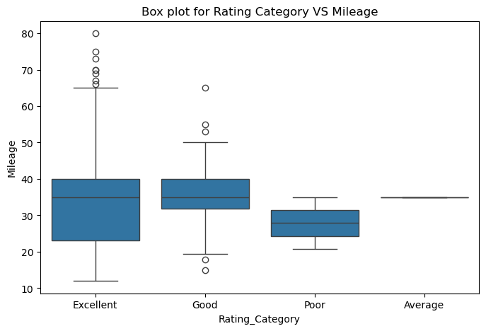

```python
plt.figure(figsize=(8,5))
sns.boxplot(data=bike_df,x='Rating_Category',y="Mileage")
plt.title("Box plot for Rating Category VS Mileage")
plt.show();
```

## Category VS Category

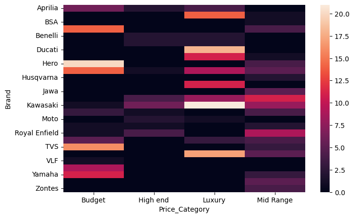

```python
a=pd.crosstab(bike_df['Brand'],bike_df['Price_Category'])
plt.figure(figsize=(8,5))
sns.heatmap(a)
plt.show();
```

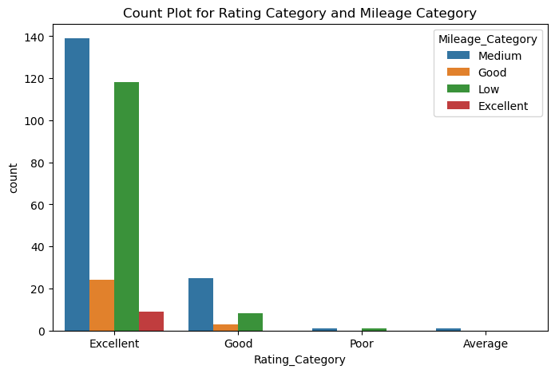

```python
plt.figure(figsize=(8,5))
sns.countplot(data=bike_df,x="Rating_Category",hue='Mileage_Category')
plt.title("Count Plot for Rating Category and Mileage Category")
plt.show();
```

# Multivatirate Analysis:

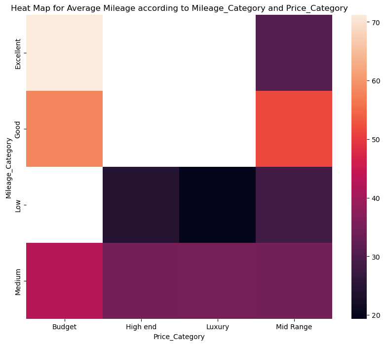

```python
a=pd.pivot_table(data=bike_df,index='Mileage_Category',columns='Price_Category',values='Mileage',aggfunc='mean')
plt.figure(figsize=(10,8))
sns.heatmap(a)
plt.title("Heat Map for Average Mileage according to Mileage_Category and Price_Category")
plt.show();
```

```python
a
```

| Price_Category Mileage_Category | Budget | High end | Luxury | Mid Range |
| --- | --- | --- | --- | --- |
| Excellent | 71.250000 | NaN | NaN | 30.500000 |
| Good | 58.147692 | NaN | NaN | 51.400000 |
| Low | NaN | 24.244444 | 19.360588 | 28.427273 |
| Medium | 42.843382 | 34.918750 | 35.000000 | 34.610870 |

[figure not shown]

```python
plt.figure(figsize=(8,5))
sns.barplot(data=bike_df,x='Price_Category',y='Power',hue='Mileage_Category',ci=False)
plt.title("Bar Plot for Brand and Mileage Category With Power")
plt.show();
```

[figure not shown]

```python
plt.figure(figsize=(8,5))
sns.boxplot(data=bike_df,x='Price_Category',y='Weight',hue='Mileage_Category')
plt.title("Bar Plot for Brand and Mileage Category With Power")
plt.show();
```